# Image-Recognition-and-Retrieval

# Machine Learning:

We will now develop our different machine learning algorithms:

### 1. Random Forest:

Random Forest is an ensemble approach to classification based on decision trees.The main principle behind ensemble methods is that a group of “weak learners” can come together to form a “strong learner”. This is basically random forest is all about.Random forest is a combination of different decision trees, default being 500 treess, combines them together, and gives the output.

Lets see how it can be used as an image classifier:

```r
train_rf <- train
test_rf <- test
train_rf$Pred <-factor(train_rf$Pred) #We factorize the Pred column for the output to be strictly among the existing values
test_rf$Pred <-factor(test_rf$Pred)
rf <- randomForest(Pred ~ .,data = train_rf) #using randomforest from randomforest package

q1 <- predict(rf, train_rf)
q2 <- predict(rf, test_rf)

#Accuracy on train set
confusionMatrix(q1, train_rf$Pred)
```

```
## Confusion Matrix and Statistics
##
##           Reference
## Prediction   0   1   2   3   4   5   6   7   8   9  10  11  12  13  14
##         0  100   0   0   0   0   0   0   0   0   0   0   0   0   0   0
##         1    0 100   0   0   0   0   0   0   0   0   0   0   0   0   0
##         2    0   0 100   0   0   0   0   0   0   0   0   0   0   0   0
##         3    0   0   0 100   0   0   0   0   0   0   0   0   0   0   0
##         4    0   0   0   0 100   0   0   0   0   0   0   0   0   0   0
##         5    0   0   0   0   0 100   0   0   0   0   0   0   0   0   0
##         6    0   0   0   0   0   0 100   0   0   0   0   0   0   0   0
##         7    0   0   0   0   0   0   0 100   0   0   0   0   0   0   0
##         8    0   0   0   0   0   0   0   0 100   0   0   0   0   0   0
##         9    0   0   0   0   0   0   0   0   0 100   0   0   0   0   0
##         10   0   0   0   0   0   0   0   0   0   0 100   0   0   0   0
##         11   0   0   0   0   0   0   0   0   0   0   0 100   0   0   0
##         12   0   0   0   0   0   0   0   0   0   0   0   0 100   0   0
##         13   0   0   0   0   0   0   0   0   0   0   0   0   0 100   0
##         14   0   0   0   0   0   0   0   0   0   0   0   0   0   0 100
##
## Overall Statistics
##
##                Accuracy : 1
##                  95% CI : (0.9975, 1)
##     No Information Rate : 0.0667
##     P-Value [Acc > NIR] : < 2.2e-16
##
##                   Kappa : 1
##  Mcnemar's Test P-Value : NA
##
## Statistics by Class:
##
##                      Class: 0 Class: 1 Class: 2 Class: 3 Class: 4 Class: 5
## Sensitivity           1.00000  1.00000  1.00000  1.00000  1.00000  1.00000
## Specificity           1.00000  1.00000  1.00000  1.00000  1.00000  1.00000
## Pos Pred Value        1.00000  1.00000  1.00000  1.00000  1.00000  1.00000
## Neg Pred Value        1.00000  1.00000  1.00000  1.00000  1.00000  1.00000
## Prevalence            0.06667  0.06667  0.06667  0.06667  0.06667  0.06667
## Detection Rate        0.06667  0.06667  0.06667  0.06667  0.06667  0.06667
## Detection Prevalence  0.06667  0.06667  0.06667  0.06667  0.06667  0.06667
## Balanced Accuracy     1.00000  1.00000  1.00000  1.00000  1.00000  1.00000
##                      Class: 6 Class: 7 Class: 8 Class: 9 Class: 10
## Sensitivity           1.00000  1.00000  1.00000  1.00000   1.00000
## Specificity           1.00000  1.00000  1.00000  1.00000   1.00000
## Pos Pred Value        1.00000  1.00000  1.00000  1.00000   1.00000
## Neg Pred Value        1.00000  1.00000  1.00000  1.00000   1.00000
## Prevalence            0.06667  0.06667  0.06667  0.06667   0.06667
## Detection Rate        0.06667  0.06667  0.06667  0.06667   0.06667
## Detection Prevalence  0.06667  0.06667  0.06667  0.06667   0.06667
## Balanced Accuracy     1.00000  1.00000  1.00000  1.00000   1.00000
##                      Class: 11 Class: 12 Class: 13 Class: 14
## Sensitivity            1.00000   1.00000   1.00000   1.00000
## Specificity            1.00000   1.00000   1.00000   1.00000
## Pos Pred Value         1.00000   1.00000   1.00000   1.00000
## Neg Pred Value         1.00000   1.00000   1.00000   1.00000
## Prevalence             0.06667   0.06667   0.06667   0.06667
## Detection Rate         0.06667   0.06667   0.06667   0.06667
## Detection Prevalence   0.06667   0.06667   0.06667   0.06667
## Balanced Accuracy      1.00000   1.00000   1.00000   1.00000
```

```r
#Accuracy of test set
confusionMatrix(q2, test_rf$Pred)
```

```
## Confusion Matrix and Statistics
##
##           Reference
## Prediction  0  1  2  3  4  5  6  7  8  9 10 11 12 13 14
##         0   4  0  0  4  1  0  0  1  1  0  1  2  0  0  1
##         1   0  1  0  0  1  0  0  0  1  0  0  0  0  0  1
##         2   0  4  2  0  0  1  0  0  0  0  4  1  1  2  1
##         3   0  1  0  5  3  1  0  1  2  0  0  0  2  0  0
##         4   1  2  0  3  5  3  0  2  3  0  1  1  1  0  1
##         5   1  1  1  1  1  7  1  0  1  0  0  1  0  0  2
##         6   2  1  3  0  0  0  9  2  1  1  0  2  1  1  0
##         7   5  1  0  1  2  0  0 10  0  0  1  1  2  0  2
##         8   1  1  1  1  0  0  0  0  3  0  1  2  0  0  0
##         9   2  2  4  1  0  2  4  0  0 12  1  1  3  5  2
##         10  2  2  1  1  1  2  0  2  2  1  5  0  4  1  2
##         11  0  0  2  1  0  0  4  0  0  1  1  8  0  0  2
##         12  0  2  1  2  3  1  0  0  3  2  1  0  5  0  2
##         13  2  2  5  0  1  2  0  1  1  3  3  0  1 10  0
##         14  0  0  0  0  2  1  2  1  2  0  1  1  0  1  4
##
## Overall Statistics
##
##                Accuracy : 0.3
##                  95% CI : (0.2487, 0.3553)
##     No Information Rate : 0.0667
##     P-Value [Acc > NIR] : < 2.2e-16
##
##                   Kappa : 0.25
##  Mcnemar's Test P-Value : NA
##
## Statistics by Class:
##
##                      Class: 0 Class: 1 Class: 2 Class: 3 Class: 4 Class: 5
## Sensitivity           0.20000 0.050000 0.100000  0.25000  0.25000  0.35000
## Specificity           0.96071 0.989286 0.950000  0.96429  0.93571  0.96429
## Pos Pred Value        0.26667 0.250000 0.125000  0.33333  0.21739  0.41176
## Neg Pred Value        0.94386 0.935811 0.936620  0.94737  0.94585  0.95406
## Prevalence            0.06667 0.066667 0.066667  0.06667  0.06667  0.06667
## Detection Rate        0.01333 0.003333 0.006667  0.01667  0.01667  0.02333
## Detection Prevalence  0.05000 0.013333 0.053333  0.05000  0.07667  0.05667
## Balanced Accuracy     0.58036 0.519643 0.525000  0.60714  0.59286  0.65714
##                      Class: 6 Class: 7 Class: 8 Class: 9 Class: 10
## Sensitivity           0.45000  0.50000  0.15000  0.60000   0.25000
## Specificity           0.95000  0.94643  0.97500  0.90357   0.92500
## Pos Pred Value        0.39130  0.40000  0.30000  0.30769   0.19231
## Neg Pred Value        0.96029  0.96364  0.94138  0.96935   0.94526
## Prevalence            0.06667  0.06667  0.06667  0.06667   0.06667
## Detection Rate        0.03000  0.03333  0.01000  0.04000   0.01667
## Detection Prevalence  0.07667  0.08333  0.03333  0.13000   0.08667
## Balanced Accuracy     0.70000  0.72321  0.56250  0.75179   0.58750
##                      Class: 11 Class: 12 Class: 13 Class: 14
## Sensitivity            0.40000   0.25000   0.50000   0.20000
## Specificity            0.96071   0.93929   0.92500   0.96071
## Pos Pred Value         0.42105   0.22727   0.32258   0.26667
## Neg Pred Value         0.95730   0.94604   0.96283   0.94386
## Prevalence             0.06667   0.06667   0.06667   0.06667
## Detection Rate         0.02667   0.01667   0.03333   0.01333
## Detection Prevalence   0.06333   0.07333   0.10333   0.05000
## Balanced Accuracy      0.68036   0.59464   0.71250   0.58036
```

We see train accuracy is 100%, and test accuracy is 30%. Accuracy can be improved by changing the depth of the algorithm.

### 2. Support Vector Machine:

Support Vector Machine (SVM) is primarily a classier method that performs classification tasks by constructing hyperplanes in a multidimensional space that separates cases of different class labels. SVM basically maximises the margin of hyperplane

```r
model_svm <- svm(Pred ~ ., data=train_rf) #svm from e1071 library is used
summary(model_svm)
```

```
##
## Call:
## svm(formula = Pred ~ ., data = train_rf)
##
##
## Parameters:
##    SVM-Type:  C-classification
##  SVM-Kernel:  radial
##        cost:  1
##       gamma:  0.0001333333
##
## Number of Support Vectors:  1496
##
##  ( 100 98 100 98 100 100 100 100 100 100 100 100 100 100 100 )
##
##
## Number of Classes:  15
##
## Levels:
##  0 1 2 3 4 5 6 7 8 9 10 11 12 13 14
```

```r
pred_svm1 <- predict(model_svm, train_rf)
pred_svm2 <- predict(model_svm, test_rf)

#Accuracy on train set
confusionMatrix(pred_svm1,train_rf$Pred)
```

```
## Confusion Matrix and Statistics
##
##           Reference
## Prediction  0  1  2  3  4  5  6  7  8  9 10 11 12 13 14
##         0  62  5  2  2  1  4  1  3  2  1  8  4  0  0  2
##         1   2 49  1  1  0  1  0  0  1  0  1  0  0  1  2
##         2   3  1 67  3  2  2  1  0  2  1  3  1  0  1  2
##         3   2  3  2 58  3  0  3  2  5  0  4  3  3  1  1
##         4   4  3  4  3 77  2  2  7  3  2  1  4  3  2  2
##         5   2  1  1  1  0 63  0  0  1  0  0  1  0  2  2
##         6   0 15  3  0  1  4 81  2  5  2  3  4  1  3  4
##         7   7  3  2  9  2 10  2 77  7  1  2 11  2  1  1
##         8   1  4  0  2  5  2  0  0 64  0  0  0  4  2  4
##         9   5  1  3  4  0  2  4  4  3 89  5  3  0  2  2
##         10  4  8  5  9  4  6  0  2  4  0 67  8  3  1  5
##         11  2  1  1  0  0  2  2  0  0  0  1 57  0  2  0
##         12  1  1  3  4  0  0  0  0  0  2  1  1 82  0  1
##         13  3  4  6  4  5  2  3  2  3  2  3  3  1 82  2
##         14  2  1  0  0  0  0  1  1  0  0  1  0  1  0 70
##
## Overall Statistics
##
##                Accuracy : 0.6967
##                  95% CI : (0.6727, 0.7199)
##     No Information Rate : 0.0667
##     P-Value [Acc > NIR] : < 2.2e-16
##
##                   Kappa : 0.675
##  Mcnemar's Test P-Value : NA
##
## Statistics by Class:
##
##                      Class: 0 Class: 1 Class: 2 Class: 3 Class: 4 Class: 5
## Sensitivity           0.62000  0.49000  0.67000  0.58000  0.77000  0.63000
## Specificity           0.97500  0.99286  0.98429  0.97714  0.97000  0.99214
## Pos Pred Value        0.63918  0.83051  0.75281  0.64444  0.64706  0.85135
## Neg Pred Value        0.97292  0.96461  0.97661  0.97021  0.98335  0.97405
## Prevalence            0.06667  0.06667  0.06667  0.06667  0.06667  0.06667
## Detection Rate        0.04133  0.03267  0.04467  0.03867  0.05133  0.04200
## Detection Prevalence  0.06467  0.03933  0.05933  0.06000  0.07933  0.04933
## Balanced Accuracy     0.79750  0.74143  0.82714  0.77857  0.87000  0.81107
##                      Class: 6 Class: 7 Class: 8 Class: 9 Class: 10
## Sensitivity           0.81000  0.77000  0.64000  0.89000   0.67000
## Specificity           0.96643  0.95714  0.98286  0.97286   0.95786
## Pos Pred Value        0.63281  0.56204  0.72727  0.70079   0.53175
## Neg Pred Value        0.98615  0.98313  0.97450  0.99199   0.97598
## Prevalence            0.06667  0.06667  0.06667  0.06667   0.06667
## Detection Rate        0.05400  0.05133  0.04267  0.05933   0.04467
## Detection Prevalence  0.08533  0.09133  0.05867  0.08467   0.08400
## Balanced Accuracy     0.88821  0.86357  0.81143  0.93143   0.81393
##                      Class: 11 Class: 12 Class: 13 Class: 14
## Sensitivity            0.57000   0.82000   0.82000   0.70000
## Specificity            0.99214   0.99000   0.96929   0.99500
## Pos Pred Value         0.83824   0.85417   0.65600   0.90909
## Neg Pred Value         0.96997   0.98718   0.98691   0.97892
## Prevalence             0.06667   0.06667   0.06667   0.06667
## Detection Rate         0.03800   0.05467   0.05467   0.04667
## Detection Prevalence   0.04533   0.06400   0.08333   0.05133
## Balanced Accuracy      0.78107   0.90500   0.89464   0.84750
```

```r
#Accuracy on test set
confusionMatrix(pred_svm2,test_rf$Pred)
```

```
## Confusion Matrix and Statistics
##
##           Reference
## Prediction  0  1  2  3  4  5  6  7  8  9 10 11 12 13 14
##         0   4  1  1  4  2  1  0  0  1  0  3  1  1  0  1
##         1   0  1  0  0  0  0  0  0  1  0  0  0  0  0  0
##         2   2  5  2  1  1  1  1  0  0  0  3  3  0  5  0
##         3   0  0  0  6  2  1  0  2  1  0  1  1  1  0  0
##         4   2  1  1  2  5  3  0  1  2  1  1  2  1  0  2
##         5   1  0  0  0  1  4  2  0  0  0  0  3  0  0  2
##         6   1  1  4  0  0  0  8  2  1  3  0  0  2  1  2
##         7   5  1  0  1  2  0  0  9  0  0  0  1  2  0  0
##         8   1  2  0  1  0  1  0  0  2  0  0  0  1  0  3
##         9   1  3  3  0  0  3  6  2  1 10  1  1  1  3  1
##         10  1  1  1  1  3  2  0  3  3  1  6  0  2  1  3
##         11  0  1  3  0  0  1  1  0  0  1  2  6  1  0  1
##         12  1  2  1  3  3  1  1  1  6  1  1  1  4  2  2
##         13  1  1  4  1  1  1  0  0  0  3  1  0  4  8  0
##         14  0  0  0  0  0  1  1  0  2  0  1  1  0  0  3
##
## Overall Statistics
##
##                Accuracy : 0.26
##                  95% CI : (0.2113, 0.3135)
##     No Information Rate : 0.0667
##     P-Value [Acc > NIR] : < 2.2e-16
##
##                   Kappa : 0.2071
##  Mcnemar's Test P-Value : NA
##
## Statistics by Class:
##
##                      Class: 0 Class: 1 Class: 2 Class: 3 Class: 4 Class: 5
## Sensitivity           0.20000 0.050000 0.100000  0.30000  0.25000  0.20000
## Specificity           0.94286 0.996429 0.921429  0.96786  0.93214  0.96786
## Pos Pred Value        0.20000 0.500000 0.083333  0.40000  0.20833  0.30769
## Neg Pred Value        0.94286 0.936242 0.934783  0.95088  0.94565  0.94425
## Prevalence            0.06667 0.066667 0.066667  0.06667  0.06667  0.06667
## Detection Rate        0.01333 0.003333 0.006667  0.02000  0.01667  0.01333
## Detection Prevalence  0.06667 0.006667 0.080000  0.05000  0.08000  0.04333
## Balanced Accuracy     0.57143 0.523214 0.510714  0.63393  0.59107  0.58393
##                      Class: 6 Class: 7 Class: 8 Class: 9 Class: 10
## Sensitivity           0.40000  0.45000 0.100000  0.50000   0.30000
## Specificity           0.93929  0.95714 0.967857  0.90714   0.92143
## Pos Pred Value        0.32000  0.42857 0.181818  0.27778   0.21429
## Neg Pred Value        0.95636  0.96057 0.937716  0.96212   0.94853
## Prevalence            0.06667  0.06667 0.066667  0.06667   0.06667
## Detection Rate        0.02667  0.03000 0.006667  0.03333   0.02000
## Detection Prevalence  0.08333  0.07000 0.036667  0.12000   0.09333
## Balanced Accuracy     0.66964  0.70357 0.533929  0.70357   0.61071
##                      Class: 11 Class: 12 Class: 13 Class: 14
## Sensitivity            0.30000   0.20000   0.40000   0.15000
## Specificity            0.96071   0.90714   0.93929   0.97857
## Pos Pred Value         0.35294   0.13333   0.32000   0.33333
## Neg Pred Value         0.95053   0.94074   0.95636   0.94158
## Prevalence             0.06667   0.06667   0.06667   0.06667
## Detection Rate         0.02000   0.01333   0.02667   0.01000
## Detection Prevalence   0.05667   0.10000   0.08333   0.03000
## Balanced Accuracy      0.63036   0.55357   0.66964   0.56429
```

We see train accuracy is 69.6% and test accuracy is 26%

Improving model accuracy: SVM model can be improved by defining radial, and finding the cost and gamma functions. The codes are commented here because it takes a long time to run.

```r
#svm_tune <- tune(svm, Pred ~ ., data = train_rf, kernel="radial", ranges=list(cost=10^(-1:2), gamma=c(.5,1,2)))
#print(svm_tune)
```

I tested the code in a very small dataset and found cost function = 0.1, and gamma function to be 0.5. Using this in our code:

```r
modelsvm_after_tune <- svm(Pred ~ ., data=train_rf, kernel="radial", cost=0.1, gamma=0.5)
summary(modelsvm_after_tune)
```

```
##
## Call:
## svm(formula = Pred ~ ., data = train_rf, kernel = "radial", cost = 0.1,
##     gamma = 0.5)
##
##
## Parameters:
##    SVM-Type:  C-classification
##  SVM-Kernel:  radial
##        cost:  0.1
##       gamma:  0.5
##
## Number of Support Vectors:  1500
##
##  ( 100 100 100 100 100 100 100 100 100 100 100 100 100 100 100 )
##
##
## Number of Classes:  15
##
## Levels:
##  0 1 2 3 4 5 6 7 8 9 10 11 12 13 14
```

```r
pred_svm3 <- predict(modelsvm_after_tune, train_rf)
pred_svm4 <- predict(modelsvm_after_tune, test_rf)

confusionMatrix(pred_svm3,train_rf$Pred)
```

```
## Confusion Matrix and Statistics
##
##           Reference
## Prediction   0   1   2   3   4   5   6   7   8   9  10  11  12  13  14
##         0  100   0   0   0   0   0   0   0   0   0   0   0   0   0   0
##         1    0 100   0   0   0   0   0   0   0   0   0   0   0   0   0
##         2    0   0 100   0   0   0   0   0   0   0   0   0   0   0   0
##         3    0   0   0 100   0   0   0   0   0   0   0   0   0   0   0
##         4    0   0   0   0 100   0   0   0   0   0   0   0   0   0   0
##         5    0   0   0   0   0 100   0   0   0   0   0   0   0   0   0
##         6    0   0   0   0   0   0 100   0   0   0   0   0   0   0   0
##         7    0   0   0   0   0   0   0 100   0   0   0   0   0   0   0
##         8    0   0   0   0   0   0   0   0 100   0   0   0   0   0   0
##         9    0   0   0   0   0   0   0   0   0 100   0   0   0   0   0
##         10   0   0   0   0   0   0   0   0   0   0 100   0   0   0   0
##         11   0   0   0   0   0   0   0   0   0   0   0 100   0   0   0
##         12   0   0   0   0   0   0   0   0   0   0   0   0 100   0   0
##         13   0   0   0   0   0   0   0   0   0   0   0   0   0 100   0
##         14   0   0   0   0   0   0   0   0   0   0   0   0   0   0 100
##
## Overall Statistics
##
##                Accuracy : 1
##                  95% CI : (0.9975, 1)
##     No Information Rate : 0.0667
##     P-Value [Acc > NIR] : < 2.2e-16
##
##                   Kappa : 1
##  Mcnemar's Test P-Value : NA
##
## Statistics by Class:
##
##                      Class: 0 Class: 1 Class: 2 Class: 3 Class: 4 Class: 5
## Sensitivity           1.00000  1.00000  1.00000  1.00000  1.00000  1.00000
## Specificity           1.00000  1.00000  1.00000  1.00000  1.00000  1.00000
## Pos Pred Value        1.00000  1.00000  1.00000  1.00000  1.00000  1.00000
## Neg Pred Value        1.00000  1.00000  1.00000  1.00000  1.00000  1.00000
## Prevalence            0.06667  0.06667  0.06667  0.06667  0.06667  0.06667
## Detection Rate        0.06667  0.06667  0.06667  0.06667  0.06667  0.06667
## Detection Prevalence  0.06667  0.06667  0.06667  0.06667  0.06667  0.06667
## Balanced Accuracy     1.00000  1.00000  1.00000  1.00000  1.00000  1.00000
##                      Class: 6 Class: 7 Class: 8 Class: 9 Class: 10
## Sensitivity           1.00000  1.00000  1.00000  1.00000   1.00000
## Specificity           1.00000  1.00000  1.00000  1.00000   1.00000
## Pos Pred Value        1.00000  1.00000  1.00000  1.00000   1.00000
## Neg Pred Value        1.00000  1.00000  1.00000  1.00000   1.00000
## Prevalence            0.06667  0.06667  0.06667  0.06667   0.06667
## Detection Rate        0.06667  0.06667  0.06667  0.06667   0.06667
## Detection Prevalence  0.06667  0.06667  0.06667  0.06667   0.06667
## Balanced Accuracy     1.00000  1.00000  1.00000  1.00000   1.00000
##                      Class: 11 Class: 12 Class: 13 Class: 14
## Sensitivity            1.00000   1.00000   1.00000   1.00000
## Specificity            1.00000   1.00000   1.00000   1.00000
## Pos Pred Value         1.00000   1.00000   1.00000   1.00000
## Neg Pred Value         1.00000   1.00000   1.00000   1.00000
## Prevalence             0.06667   0.06667   0.06667   0.06667
## Detection Rate         0.06667   0.06667   0.06667   0.06667
## Detection Prevalence   0.06667   0.06667   0.06667   0.06667
## Balanced Accuracy      1.00000   1.00000   1.00000   1.00000
```

```r
confusionMatrix(pred_svm4,test_rf$Pred)
```

```
## Confusion Matrix and Statistics
##
##           Reference
## Prediction  0  1  2  3  4  5  6  7  8  9 10 11 12 13 14
##         0   0  0  0  0  0  0  0  0  0  0  0  0  0  0  0
##         1   0  0  0  0  0  0  0  0  0  0  0  0  0  0  0
##         2   0  0  0  0  0  0  0  0  0  0  0  0  0  0  0
##         3   0  0  0  0  0  0  0  0  0  0  0  0  0  0  0
##         4   0  0  0  0  0  0  0  0  0  0  0  0  0  0  0
##         5   0  0  0  0  0  1  0  0  0  0  0  0  0  0  0
##         6   0  0  0  0  0  0  0  0  0  0  0  0  0  0  0
##         7   1  0  0  0  0  0  0  0  0  0  0  0  0  0  0
##         8   0  0  0  0  0  0  0  0  0  0  0  0  0  0  0
##         9   0  0  0  0  0  0  0  0  0  0  0  0  0  0  0
##         10  0  0  0  0  0  0  0  0  0  0  0  0  0  0  0
##         11 19 20 20 20 20 19 20 20 20 20 20 20 20 20 20
##         12  0  0  0  0  0  0  0  0  0  0  0  0  0  0  0
##         13  0  0  0  0  0  0  0  0  0  0  0  0  0  0  0
##         14  0  0  0  0  0  0  0  0  0  0  0  0  0  0  0
##
## Overall Statistics
##
##                Accuracy : 0.07
##                  95% CI : (0.0439, 0.105)
##     No Information Rate : 0.0667
##     P-Value [Acc > NIR] : 0.4409
##
##                   Kappa : 0.0036
##  Mcnemar's Test P-Value : NA
##
## Statistics by Class:
##
##                      Class: 0 Class: 1 Class: 2 Class: 3 Class: 4 Class: 5
## Sensitivity           0.00000  0.00000  0.00000  0.00000  0.00000 0.050000
## Specificity           1.00000  1.00000  1.00000  1.00000  1.00000 1.000000
## Pos Pred Value            NaN      NaN      NaN      NaN      NaN 1.000000
## Neg Pred Value        0.93333  0.93333  0.93333  0.93333  0.93333 0.936455
## Prevalence            0.06667  0.06667  0.06667  0.06667  0.06667 0.066667
## Detection Rate        0.00000  0.00000  0.00000  0.00000  0.00000 0.003333
## Detection Prevalence  0.00000  0.00000  0.00000  0.00000  0.00000 0.003333
## Balanced Accuracy     0.50000  0.50000  0.50000  0.50000  0.50000 0.525000
##                      Class: 6 Class: 7 Class: 8 Class: 9 Class: 10
## Sensitivity           0.00000 0.000000  0.00000  0.00000   0.00000
## Specificity           1.00000 0.996429  1.00000  1.00000   1.00000
## Pos Pred Value            NaN 0.000000      NaN      NaN       NaN
## Neg Pred Value        0.93333 0.933110  0.93333  0.93333   0.93333
## Prevalence            0.06667 0.066667  0.06667  0.06667   0.06667
## Detection Rate        0.00000 0.000000  0.00000  0.00000   0.00000
## Detection Prevalence  0.00000 0.003333  0.00000  0.00000   0.00000
## Balanced Accuracy     0.50000 0.498214  0.50000  0.50000   0.50000
##                      Class: 11 Class: 12 Class: 13 Class: 14
## Sensitivity           1.000000   0.00000   0.00000   0.00000
## Specificity           0.007143   1.00000   1.00000   1.00000
## Pos Pred Value        0.067114       NaN       NaN       NaN
## Neg Pred Value        1.000000   0.93333   0.93333   0.93333
## Prevalence            0.066667   0.06667   0.06667   0.06667
## Detection Rate        0.066667   0.00000   0.00000   0.00000
## Detection Prevalence  0.993333   0.00000   0.00000   0.00000
## Balanced Accuracy     0.503571   0.50000   0.50000   0.50000
```

CNNs are the category of Neural Network that are currently considered as the best algorithm for working on images. CNNs are pre-dominantly used for identifying faces, objects and traffic signs apart from powering vision in robots and self driving cars.

It is also important to have keras installed in python, because the R package calls keras from python in the backend. Also, if you have multiple python notebook/consoles, the code will throw an error. Now lets get started:

```r
#We cannot directly feed the previous train data here. As such, we will be doing certain changes



train_cnn <- zz[c(0:100,121:220,241:340,361:460,481:580, 601:700,721:820,841:940,961:1060,1081:1180, 1201:1300,1321:1420,1441:1540,1561:1660, 1681:1780),]
test_cnn <- zz[c(101:120, 221:240 ,341:360,461:480,581:600, 701:720,821:840,941:960, 1061:1080, 1181:1200,1301:1320,1421:1440,1541:1560,1661:1680,1781:1800),]
trainlabels_cnn <- a1[c(0:100,121:220,241:340,361:460,481:580, 601:700,721:820,841:940,961:1060,1081:1180, 1201:1300,1321:1420,1441:1540,1561:1660, 1681:1780),]
testlabels_cnn <- a1[c(101:120, 221:240 ,341:360,461:480,581:600, 701:720,821:840,941:960, 1061:1080, 1181:1200,1301:1320,1421:1440,1541:1560,1661:1680,1781:1800),]
train_t <- as.numeric(g[c(0:100,121:220,241:340,361:460,481:580, 601:700,721:820,841:940,961:1060,1081:1180, 1201:1300,1321:1420,1441:1540,1561:1660, 1681:1780),1])
test_t <- as.numeric(g[c(101:120, 221:240 ,341:360,461:480,581:600, 701:720,821:840,941:960, 1061:1080, 1181:1200,1301:1320,1421:1440,1541:1560,1661:1680,1781:1800),1])
trainlabelscnn2 <- as.matrix(trainlabels_cnn)
testlabelscnn2 <- as.matrix(testlabels_cnn)
library(keras)

train_cnn2 <- as.matrix(train_cnn)
test_cnn2 <- as.matrix(test_cnn)

#We will use the pipe operator here, denoted by %>%. It  is used for chaining expressions together. Here LHS is first evaluated and putting the result of LHS in placeholder, RHS is calculated.


#Keras has two types of model: sequential and models created with functional api. Sequential models are created using the keras_model_sequential() function and are composed of a set of linear stack of layers

model <- keras_model_sequential()

#defining hidden layers
model %>%
  layer_dense(units = 15, activation = 'relu', input_shape = c(7500)) %>%
  layer_dense(units = 25, activation = 'relu') %>%
  layer_dense(units = 15, activation = 'softmax')
summary(model)
```

```
## ___________________________________________________________________________
## Layer (type)                     Output Shape                  Param #
## ===========================================================================
## dense_1 (Dense)                  (None, 15)                    112515
## ___________________________________________________________________________
## dense_2 (Dense)                  (None, 25)                    400
## ___________________________________________________________________________
## dense_3 (Dense)                  (None, 15)                    390
## ===========================================================================
## Total params: 113,305
## Trainable params: 113,305
## Non-trainable params: 0
## ___________________________________________________________________________
```

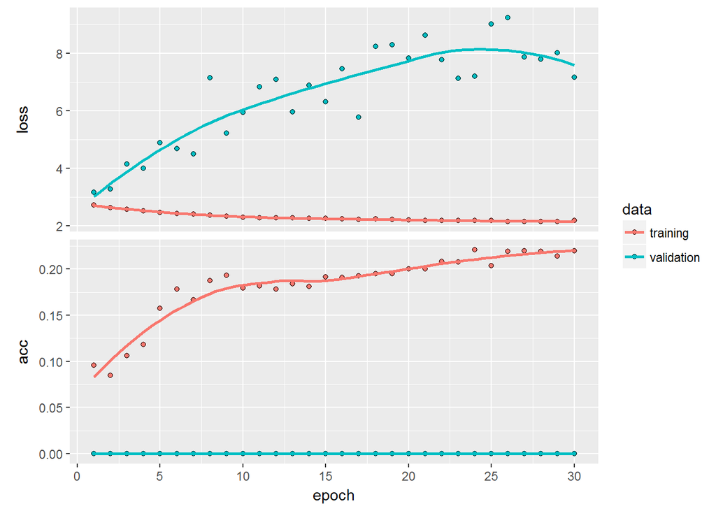

```r
#compile, i.e. configure a keras model for training.
model %>%
  compile(loss = 'categorical_crossentropy', #we use categorical for multiclass classifier. For only 2 classes, one can use binary_crossentropy
  optimizer = 'adam', #Adam optimization algorithm is an extension to stochastic gradient descent that has recently seen broader adoption for deep learning applications in computer vision and natural language processing
  metrics = 'accuracy')

#Fit Mode: training the keras model
  history <- model %>%
    fit(train_cnn2, trainlabels_cnn, epochs = 30, batch_size = 32, validation_split = 0.2)

  plot(history)
```

```r
#evaluate
  #model %>%
   # evaluate(train_cnn2, trainlabelscnn2)

 model %>%
    evaluate(test_cnn2, testlabelscnn2)
```

```
## $loss
## [1] 3.418324
##
## $acc
## [1] 0.1366667
```

```r
  # Prediction & confusion matrix - test data
  prob <- model %>%
    predict_proba(test_cnn2)

  pred1 <- model %>%
    predict_classes(train_cnn2)

  pred2 <- model %>%
    predict_classes(test_cnn2)

  table1 <- table(Predicted = pred1, Actual = train_t)
  table1
```

```
##          Actual
## Predicted  0  1  2  3  4  5  6  7  8  9 10 11 12 13 14
##        0  16 15 12 15  9 12 11 14 13 11 19 15 27 19 25
##        1   6 11  9  2  0  4 12  4  9 19  7  0  4  9  7
##        2   1  0  3  0  0  3  1  0  1  1  0  2  0  0  0
##        3  25 14  7 36 29 11  5 17 17  8 32  9 22 18 12
##        4  32  8  9 37 58  9  0 57 28  1  8  8 28 10 10
##        5   2  0  2  1  1 23  1  0  0  3  1 10  1  5  2
##        6   7 40 34  1  0  7 61  0 19 32 13  1  3 16 20
##        7   0  0  0  0  2  0  0  3  0  0  0  0  1  0  2
##        9   8 10 20  6  0  6  8  3  9 24 14  5  7 18 11
##        10  1  1  0  1  0  2  0  0  1  0  1  0  1  1  1
##        11  2  1  4  1  1 23  1  2  3  1  5 50  6  4 10
```

```r
  table2 <- table(Predicted = pred2, Actual = test_t)
  table2
```

```
##          Actual
## Predicted  0  1  2  3  4  5  6  7  8  9 10 11 12 13 14
##        0   5  2  4  3  3  6  2  3  4  6  2  1  4  6  3
##        1   0  2  3  0  2  0  2  0  1  2  1  1  1  2  1
##        2   0  0  1  0  0  0  1  0  0  0  0  1  0  0  0
##        3   4  1  3  8  7  3  1  4  6  1  2  3  6  0  1
##        4   4  4  1  4  7  3  0 10  4  2  4  3  3  1  3
##        5   1  0  1  0  1  4  1  0  0  0  0  8  0  0  1
##        6   3  7  4  0  0  1  9  2  3  3  1  2  1  5  5
##        9   1  3  1  4  0  0  3  1  2  4  6  0  4  4  3
##        10  0  0  0  0  0  0  0  0  0  1  0  0  0  1  0
##        11  2  1  2  1  0  3  1  0  0  1  4  1  1  1  3
```

# Multiclass Nomial Logistic Regression: When it works and when it doesnt?

Image classificaton can also be implemented using multinom package in r as below:

```r
#library(mlogit)
#library(nnet)
#library(caret)


#model <- multinom(Pred ~ .,data = train, MaxNWts = 999999999999999999999999999)
#p1 <- predict(model, train)
#p2 <- predict(model, test)

#confusionMatrix(p1, train$Pred)

#confusionMatrix(p2, test$Pred)
```

Lets try to make this code run with only two classes and see how it fares:

```r
ne <- as.data.frame(rbind(blouse[1:25,], jacket[1:25,]))
nd <- rep(0:1, each = 25)
nb <- as.data.frame(nd)
colnames(nb) <- "Pred"
ft <- cbind(nb, ne)
train_mul <- ft[c(0:20,26:45),]
test_mul <- ft[c(21:25,46:50),]
model_mul <- multinom(Pred ~ .,data = train_mul, MaxNWts = 999999999999999999999999999)
p1 <- predict(model_mul, train_mul)
p2 <- predict(model_mul, test_mul)

confusionMatrix(p1, train_mul$Pred)
```

```
## Confusion Matrix and Statistics
##
##           Reference
## Prediction  0  1
##          0 20  0
##          1  0 20
##
##                Accuracy : 1
##                  95% CI : (0.9119, 1)
##     No Information Rate : 0.5
##     P-Value [Acc > NIR] : 9.095e-13
##
##                   Kappa : 1
##  Mcnemar's Test P-Value : NA
##
##             Sensitivity : 1.0
##             Specificity : 1.0
##          Pos Pred Value : 1.0
##          Neg Pred Value : 1.0
##              Prevalence : 0.5
##          Detection Rate : 0.5
##    Detection Prevalence : 0.5
##       Balanced Accuracy : 1.0
##
##        'Positive' Class : 0
##
```

```r
confusionMatrix(p2, test_mul$Pred)
```

```
## Confusion Matrix and Statistics
##
##           Reference
## Prediction 0 1
##          0 4 4
##          1 1 1
##
##                Accuracy : 0.5
##                  95% CI : (0.1871, 0.8129)
##     No Information Rate : 0.5
##     P-Value [Acc > NIR] : 0.6230
##
##                   Kappa : 0
##  Mcnemar's Test P-Value : 0.3711
##
##             Sensitivity : 0.8
##             Specificity : 0.2
##          Pos Pred Value : 0.5
##          Neg Pred Value : 0.5
##              Prevalence : 0.5
##          Detection Rate : 0.4
##    Detection Prevalence : 0.8
##       Balanced Accuracy : 0.5
##
##        'Positive' Class : 0
##
```

So we see that while the algorithm works, it gives a stiff challenge on memory utilisation, and hence should be very rarely used for large image classification.

Sources:

1. http://blog.citizennet.com/blog/2012/11/10/random-forests-ensembles-and-performance-metrics
2. http://www.statsoft.com/Textbook/Support-Vector-Machines
3. https://towardsdatascience.com/support-vector-machines-a-brief-overview-37e018ae310f
4. https://docs.hhvm.com/hack/operators/pipe-operator
5. https://keras.rstudio.com/articles/about_keras_models.html